# Bitácora técnica y de limpieza de datos

Análisis de sentimientos y emociones — Telegram Temporada 2026

Chavez Gutierrez Eddy Yojan

Copa Quispe Esther Sara

Rojas Condori Fidel Angel

Reyes Barja Carlos Eduardo

28 de octubre de 2026

DATA MINING · PARALELO A Proyecto concluido

Universidad Mayor de San Andrés · Facultad de Ciencias Puras y Naturales · Carrera de Informática

# Bitácora técnica y de limpieza de datos

Registro reproducible del análisis de sentimientos y emociones del grupo de Telegram de Temporada 2026.

Docente**M.Sc. Menfy Morales Rios**

Periodo analizado**16/12/2022 – 12/10/2026**

Última actualización**26/10/2026**

Ver línea de tiempo

01

Estado del proyecto

## Resumen ejecutivo de la bitácora

Esta página documenta las decisiones que transformaron 29 archivos HTML de Telegram en un corpus limpio, una referencia humana adjudicada y un modelo evaluado sin fuga de duplicados.

Corpus final**21.546**mensajes válidos

Muestra humana**1.085**filas × 2 anotadores

Emociones modeladas**10**soporte mínimo ≥ 20

Controles finales**0**errores y objetivos vacíos

✓

### Qué registra

Problemas detectados, decisiones, filas verificadas, responsables, scripts y productos obtenidos.

↻

### Cómo se reproduce

Cada etapa apunta al archivo R o Python que genera o valida el resultado.

◈

### Cómo se protege

El texto queda en archivos privados; las salidas de presentación son agregadas.

**Lectura recomendada:** primero revise la línea de tiempo; luego use los filtros de la tabla de auditoría para localizar una acción, dataset o script específico.

02

Metodología solicitada

## Seis controles de limpieza aplicados

La guía de `bitacora.pdf` se adaptó a datos textuales. No se aplicaron reglas numéricas de manera mecánica cuando podían eliminar mensajes válidos.

1

### Auditoría inicial

Tipos, fechas, cardinalidades, ausencias, longitud, URL y emojis.

- 29 HTML
- 21.546 IDs únicos
- 0 textos o fechas faltantes

2

### Formatos

Fechas ISO-8601, hora entera, Unicode, espacios y etiquetas normalizadas.

- Texto original preservado
- URL convertidas a marcador

3

### Duplicados

No había IDs duplicados; los textos repetidos se conservaron como eventos reales.

- 17.457 textos únicos
- Agrupación por hash en evaluación

4

### Faltantes

No se imputaron emociones ni texto. Un objetivo incompleto detiene el pipeline.

- 1.085 objetivos completos
- Adjudicación humana

5

### Atípicos

Se perfilaron longitudes y señales, pero no se eliminó un mensaje solo por ser largo.

- Mediana: 41 caracteres
- Máximo: 2.646 caracteres

6

### Consistencia

Catálogos válidos, reglas entre variables, privacidad y pruebas sin fuga.

- 0 errores finales
- 10 emociones evaluadas

Decisión metodológica clave

### Un dato extremo no es necesariamente un error

En datos textuales, una publicación larga puede ser un anuncio académico válido. IQR y Z-score se usaron como referencias de perfilado, no como órdenes automáticas de eliminación.

Texto faltante**0**

ID duplicado**0**

Mensajes con URL**1.433**

03

Evolución verificable

## Línea de tiempo del proyecto

La bitácora distingue resultados intermedios de resultados finales. Esto evita presentar como definitiva una métrica obtenida mientras el etiquetado aún estaba incompleto.

21OCT

Preparación

### Extracción, diccionario y privacidad

Completado

- Revisión de las 15 categorías del documento base.
- Lectura automática de `messages.html`, `messages2.html`, etc.
- Pseudonimización de 1.594 participantes.
- Separación entre polaridad neutral y ausencia de coincidencia.
- Clasificación multietiqueta y bitácora con huellas MD5.

Producto**Corpus de 21.546 mensajes**`01_ejecutar_analisis.R`

21OCT

Cobertura

### Ampliación contextual del diccionario

Completado

Se mantuvo el diccionario original como baseline y se creó `ampliado_v2` con expresiones del dominio, variantes, emojis y emoticonos.

Original**9,4%**2.034 mensajes

→

Ampliado**24,6%**5.299 mensajes

Impacto**+3.265 mensajes con evidencia**`crear_diccionario()`

21OCT

Dataset

### Muestra, librerías y libro de códigos

Completado

- Muestra estratificada por gestión y señal emocional, con refuerzo sin evidencia.
- Plantillas separadas para anotadores A y B.
- `tm` para corpus y limpieza; `quanteda` para tokens y DFM; `syuzhet` como referencia auxiliar.
- Matriz documento-término de 21.546 × 10.421.

Producto**1.085 mensajes seleccionados**`02_generar_dataset_manual.R`

26OCT

Resultado intermedio

### Consenso parcial y benchmark preliminar

Superado

En esta versión B tenía 713 filas completas. Se corrigieron tres valores mecánicos y se compararon modelos sobre 300 acuerdos. Las métricas no se consideraron finales.

Kappa polaridad **0,481**Kappa emoción **0,498**Filas B **713**

Lección**No presentar un benchmark parcial como conclusión**`08_modelo_embeddings.py`

26OCT

Resultado final

### Doble anotación y adjudicación completa

Validado

A y B completaron las 1.085 filas. Los desacuerdos se adjudicaron sin sobrescribir las decisiones originales.

Kappa polaridad **0,418**Kappa emoción **0,432**Errores finales **0**

Producto**`dataset_modelado_umsa.csv`**`07_consolidar_adjudicaciones.R`

26OCT

Modelado

### Validación cruzada y clasificación final

Validado

- Cinco folds estratificados y agrupados por hash de texto.
- Comparación de baseline, diccionario, TF-IDF, MiniLM e híbrido.
- Selección de TF-IDF + MiniLM mediante macro-F1.
- Predicción de 21.546 mensajes sin exportar texto ni participante.

Macro-F1 polaridad**0,393**

Macro-F1 emociones**0,375**

Emociones**10**

Scripts**Evaluación y aplicación final**`09_validacion_cruzada.py · 10_clasificar_corpus.py`

04

Audit trail

## Registro de transformaciones

Busque por término o filtre por área. El contador se actualiza inmediatamente.

Buscar Área Fecha

**14**registros visibles

01

21/10/2026 · INGESTA

### Orden de archivos HTML

Se localizaron y ordenaron 29 archivos `messages*.html` antes de extraer el contenido.

Verificado**29 archivos**`R/funciones.R`

02

21/10/2026 · INGESTA

### Extracción y fechas

Se conservaron mensajes textuales con fecha válida y se transformaron las fechas al estándar ISO.

Resultado**21.546 filas**`01_ejecutar_analisis.R`

03

21/10/2026 · PRIVACIDAD

### Pseudonimización

Los autores se sustituyeron por códigos `P001`, `P002`, etc.

Protegido**1.594 participantes**`extraer_mensajes()`

04

21/10/2026 · LIMPIEZA

### Normalización textual

Unicode, espacios, URL, minúsculas y señales gráficas; el texto original se mantuvo para auditoría.

Verificado**21.546 filas**`normalizar_texto()`

05

21/10/2026 · LIMPIEZA

### Unicidad de identificadores

Se comprobó que cada mensaje tuviera un identificador único.

Anomalías**0 duplicados de ID**`01_ejecutar_analisis.R`

06

21/10/2026 · LIMPIEZA

### Textos repetidos

Las repeticiones reales se conservaron; en modelado se agruparon para evitar fuga.

Perfil**17.457 textos únicos**`text_group()`

07

21/10/2026 · DICCIONARIO

### Ampliación contextual

Se añadieron variantes, expresiones, emojis y emoticonos manteniendo el original como baseline.

Cobertura**9,4% → 24,6%**`crear_diccionario()`

08

21/10/2026 · DATASET

### Muestreo reproducible

Estratificación por gestión y señal emocional, más refuerzo de mensajes sin evidencia.

Seleccionado**1.085 filas**`02_generar_dataset_manual.R`

09

26/10/2026 · VALIDACIÓN

### Correcciones mecánicas de B

Se normalizaron tres valores inválidos documentados sin inferir etiquetas semánticas.

Corregido**3 celdas**`06_corregir_etiquetado_b.R`

10

26/10/2026 · VALIDACIÓN

### Control final A/B

Catálogos, obligatoriedad, duplicados y consistencia estructural.

Válido**2.170 anotaciones**`03_validar_dataset_manual.R`

11

26/10/2026 · CONSENSO

### Adjudicación

Los desacuerdos se resolvieron en un archivo separado y se registró la fuente del objetivo.

Resuelto**447 polaridades · 604 emociones**`07_consolidar_adjudicaciones.R`

12

26/10/2026 · MODELO

### Duplicados entre folds

Los textos normalizados idénticos se agruparon mediante SHA-256.

Controlado**77 repeticiones**`09_validacion_cruzada.py`

13

26/10/2026 · SELECCIÓN

### Comparación justa

Se usó macro-F1 para comparar cinco alternativas bajo las mismas predicciones OOF.

Ganador**TF-IDF + MiniLM**`09_validacion_cruzada.py`

14

26/10/2026 · PRIVACIDAD

### Salida final minimizada

Las predicciones excluyen texto y participante; solo conservan ID, tiempo, clase y confianza.

Protegido**21.546 predicciones**`10_clasificar_corpus.py`

05

Controles finales

## Calidad y trazabilidad

Las siguientes cifras corresponden al estado final, después de completar y adjudicar todas las filas.

### Acuerdo humano

Kappa polaridad

**0,418**

Kappa emoción principal

**0,432**

Jaccard emocional

**0,523**

El acuerdo moderado demuestra ambigüedad real y justifica la adjudicación.

### Integridad del dataset

- ✓1.085 filas completas de A
- ✓1.085 filas completas de B
- ✓0 categorías inválidas finales
- ✓0 objetivos vacíos
- ✓Fuente de cada objetivo registrada

### Evaluación del modelo

Polaridad**0,393**macro-F1 OOF

Emociones**0,375**macro-F1 OOF

Cinco folds, grupos de texto y selección entre modelos aprendidos.

**Interpretación:** una métrica moderada no se oculta. El acuerdo humano también es moderado, varias clases tienen pocos ejemplos y el mensaje se analiza sin toda la conversación anterior.

06

Salidas reproducibles

## Evidencias visuales

Las capturas se generan mediante scripts. No contienen nombres ni conversaciones privadas.

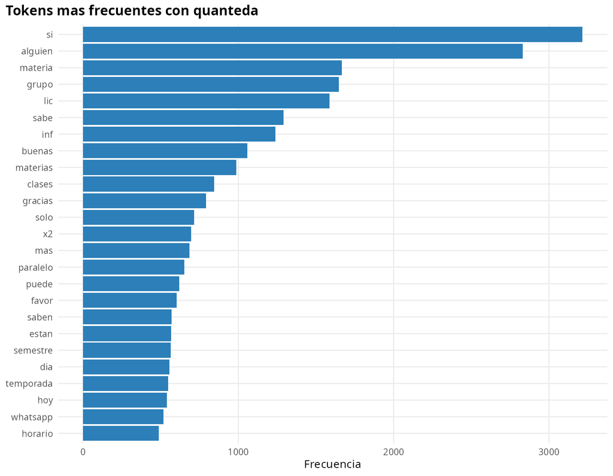

**Preprocesamiento**Frecuencia de tokens después de limpieza.

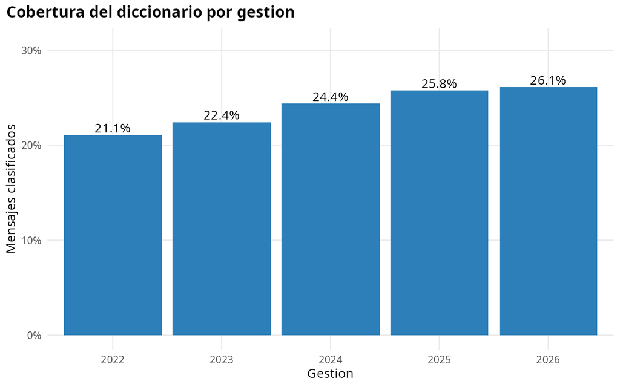

**Diccionario**Cobertura contextual por gestión.

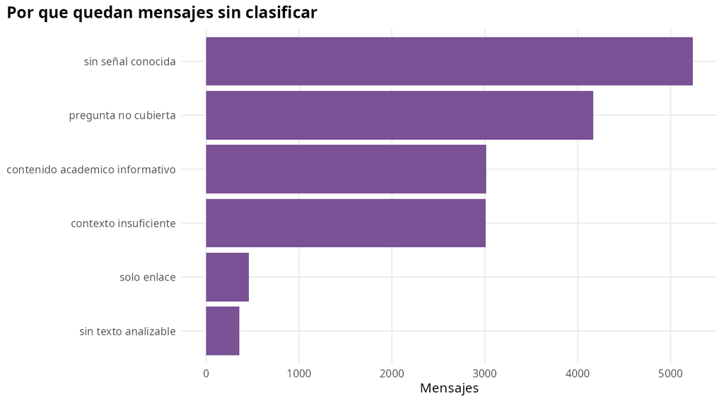

**Diagnóstico**Motivos operativos de ausencia de evidencia.

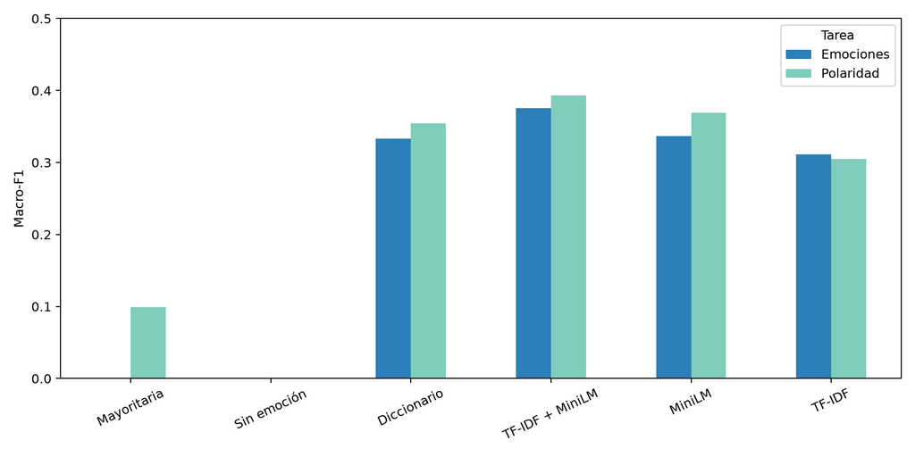

**Modelos**Comparación fuera de muestra.

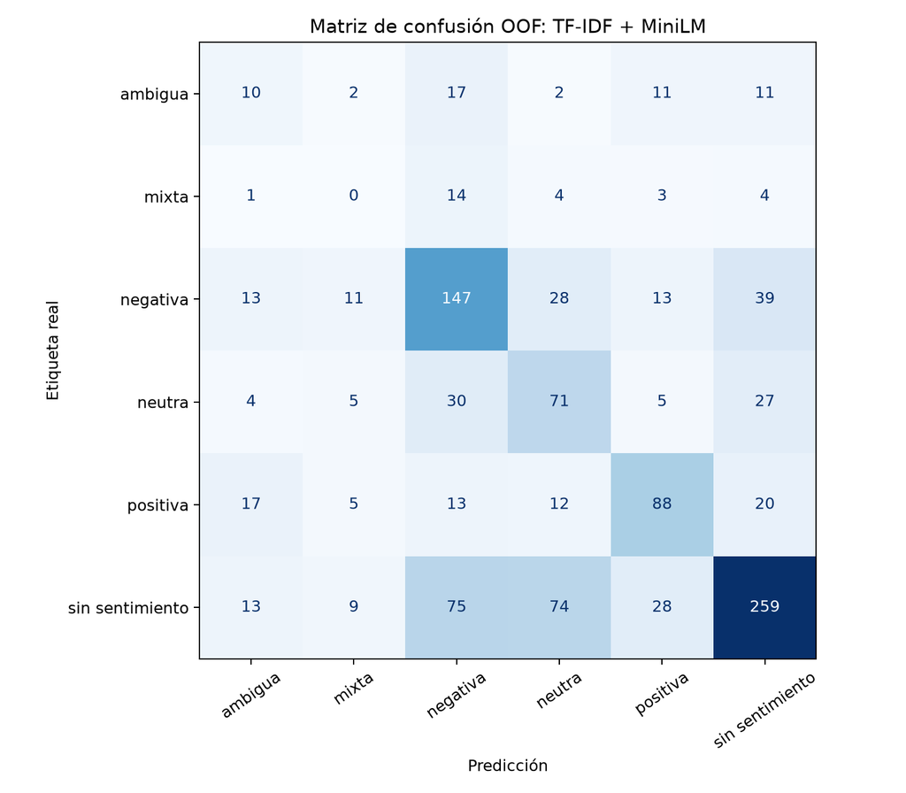

**Polaridad**Matriz de confusión del híbrido.

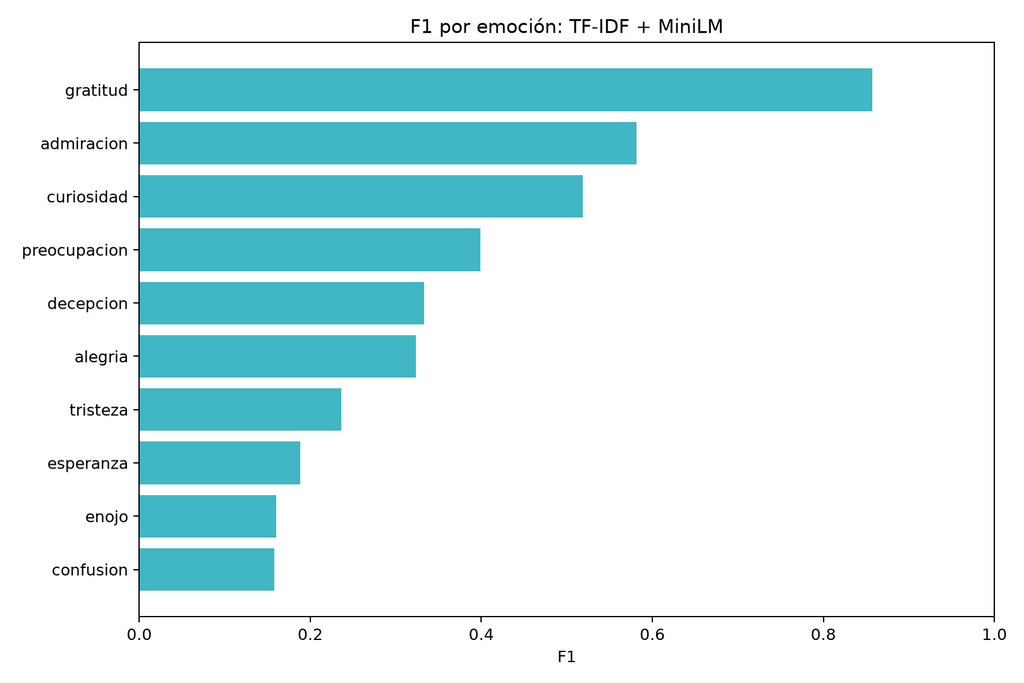

**Emociones**Rendimiento de las diez clases.

07

Cómo repetirlo

## Secuencia reproducible

Los comandos deben ejecutarse desde la raíz del proyecto.

```bash
Rscript scripts/01_ejecutar_analisis.R
Rscript scripts/02_generar_dataset_manual.R
Rscript scripts/06_corregir_etiquetado_b.R
Rscript scripts/03_validar_dataset_manual.R
Rscript scripts/07_consolidar_adjudicaciones.R
Rscript scripts/04_mineria_descriptiva.R
Rscript scripts/05_preprocesamiento_librerias.R

HF_HUB_OFFLINE=1 TRANSFORMERS_OFFLINE=1 \
  .venv-embeddings/bin/python scripts/09_validacion_cruzada.py

HF_HUB_OFFLINE=1 TRANSFORMERS_OFFLINE=1 \
  .venv-embeddings/bin/python scripts/10_clasificar_corpus.py --batch-size 256
```

Bitácora humana`BITACORA.md`

Decisiones, cambios de alcance y resultados.

Bitácora automática`bitacora_ejecuciones.csv`

Fechas, cantidades y huellas MD5.

Referencia final`dataset_modelado_umsa.csv`

Objetivos y fuente de la adjudicación.

Evaluación final`comparacion_modelos.csv`

Métricas fuera de muestra.

08

Cierre

## Observaciones y decisiones abiertas

### Documento base

El pie del PDF de emociones contiene una nota ambigua sobre posibles reemplazos de categorías. Se conservaron las quince categorías definidas en el cuerpo y se recomienda confirmar esa interpretación con la docente.

### Privacidad

Los CSV con texto se entregan solo con fines académicos. No deben publicarse en un repositorio abierto. Las figuras y predicciones de presentación no incluyen participantes.

### Alcance

El resultado identifica señales lingüísticas agregadas. No diagnostica emociones reales de estudiantes ni debe utilizarse para evaluar individuos.

**Responsables del proyecto**

Chavez Gutierrez Eddy Yojan Copa Quispe Esther Sara Rojas Condori Fidel Angel Reyes Barja Carlos Eduardo